# PISA 2012 Assessment

## by Amira Noaman

PISA is a survey of students' skills and knowledge as they approach the end of compulsory education. The aim of this test is to examine how well students have digested the school curriculum and how well prepared they are for life beyond school. Approximately a half million students in 65 economies joined the PISA 2012 assessment of reading, mathematics and science representing about 28 million 15-year-olds globally.

The full 2012 PISA dataset can be found [here.](https://s3.amazonaws.com/udacity-hosted-downloads/ud507/pisa2012.csv.zip)

The PISA data dictionary, which gives a brief explaination of each feature, can be found [here.](https://s3.amazonaws.com/udacity-hosted-downloads/ud507/pisadict2012.csv)

### BRIEF DATA CLEANING PROCESS

For our data cleaning process, we focused on features that dealt with the country, gender, wealth index, math score,science score, reading score, student motivation level & if the student has internet or not. Concerning the student's motivation subcategories, I assigned points and took the average to represent the overall score for each subcategory. To clarify, there are 4 questions related to motivation: (worthwhile for work, worthwhile for career changes, important for future study, and helps to get a job). Each of these questions can be answered by either 'Strongly Agree', 'Agree', 'Disagree','Strongly Disagree.' After focusing on only certain features as well as combining features, we are left with a total of 8 features.

**OUR FINAL FEATURES**

- **country**
- **gender**
- **wealth_index**
- **math_score**: student's math score
- **reading_score**: student's reading score
- **science_score**: student's science score
- **motivation**: Average score for 4 other features
- **internet**: possession of internet

```python
# import all packages and set plots to be embedded inline
import numpy as np
import pandas as pd
import matplotlib.pyplot as plt
import seaborn as sb

%matplotlib inline
```

```python
df = pd.read_csv('pisa2012_clean.csv', encoding='latin-1')
df.head()
```

|  | country | gender | wealth_index | math_score | reading_score | science_score | internet_possession | motivation |
| --- | --- | --- | --- | --- | --- | --- | --- | --- |
| 0 | Albania | Female | -2.92 | 406.8469 | 249.5762 | 341.7009 | No | 3.50 |
| 1 | Albania | Female | 0.69 | 486.1427 | 406.2936 | 548.9929 | Yes | 2.75 |
| 2 | Albania | Female | -0.23 | 533.2684 | 401.2100 | 499.6643 | Yes | 4.00 |
| 3 | Albania | Female | -1.17 | 412.2215 | 547.3630 | 438.6796 | Yes | NaN |
| 4 | Albania | Female | -1.17 | 381.9209 | 311.7707 | 361.5628 | Yes | 4.00 |

```python
df.shape
```

```
(485490, 8)
```

### What is the structure of your dataset?

My dataset contains information about 485,490 students and presents 8 features.

### What is/are the main feature(s) of interest in your dataset?

1. Internet Possession
2. Motivation
3. Wealth
4. Country
5. Gender

For my analysis, I was interested to find the relation between the presence of internet and whether it affects the academic performance or make it worse. Also I wanted to consider the students' financial level and also his/her enthusiasm/motivation. I also believe I could gain a lot of information by taking the country into account for example I can inspect patterns of top countries with high scores and the countries of wealthiest/cleverest students.

### What features in the dataset do you think will help support your investigation into your feature(s) of interest?

I sorted the features here accordance to the most important at the top to the least important at the bottom. I believe that the features at the top will have a significant impact on the academic scores. Sometimes it's claimed that females are more dedicated than males but I believe there is not correlation between them so I'm waiting to check the pattern

# Univariate Exploration

### Scores

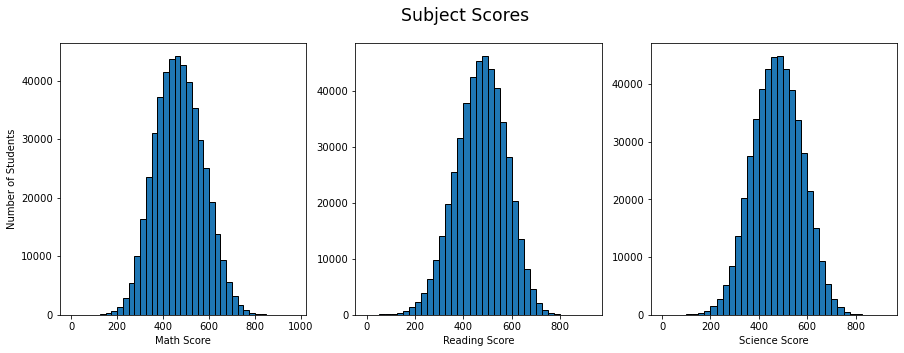

```python
# Select bin size
binsize = 25

plt.figure(figsize=[15, 5])
plt.suptitle('Subject Scores', size='xx-large')

# Plot Math
plt.subplot(1, 3, 1)
bins = np.arange(0, df['math_score'].max()+binsize, binsize)
plt.hist(data = df, x = 'math_score', bins = bins,histtype='bar',ec='black')
plt.xlabel('Math Score')
plt.ylabel('Number of Students')

# Plot Reading
plt.subplot(1, 3, 2)
bins = np.arange(0, df['reading_score'].max()+binsize, binsize)
plt.hist(data = df, x = 'reading_score', bins = bins, histtype='bar',ec='black')
plt.xlabel('Reading Score')

# Plot Science
plt.subplot(1, 3, 3)
bins = np.arange(0, df['science_score'].max()+binsize, binsize)
plt.hist(data = df, x = 'science_score', bins = bins, histtype='bar',ec='black')
plt.xlabel('Science Score');
```

**All scores appear normally distributed with a peak around 500**

### Gender

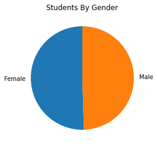

```python
plt.pie(df['gender'].value_counts(), labels=df['gender'].value_counts().index,startangle=90)
plt.title('Students By Gender');
```

**The number of females & males are almost equal**

### Wealth index

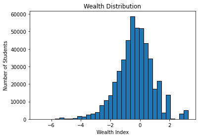

```python
# Create appropriate bins
binsize = 0.3
bins = np.arange(df['wealth_index'].min()-binsize, df['wealth_index'].max()+binsize, binsize)

# Plot
plt.hist(data = df, x = 'wealth_index', bins = bins, histtype='bar', ec='black')
plt.title('Wealth Distribution')
plt.ylabel('Number of Students')
plt.xlabel('Wealth Index');
```

**Wealth distribution is slightly left skewed. At the right side there are some outliers that should be checked**

### Country

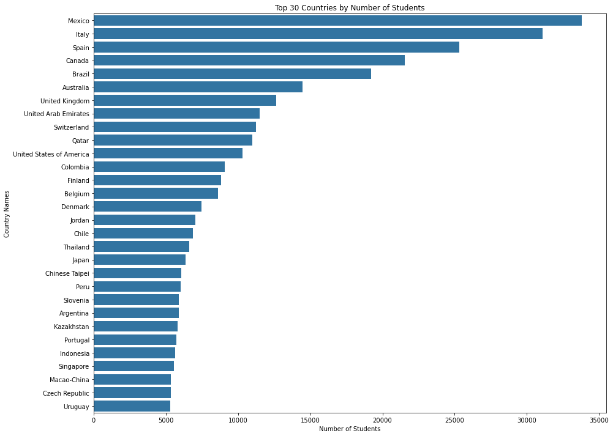

```python
# Get default color from palette
base_color = sb.color_palette()[0]
# Get top 30 countries
data = df['country'].value_counts().head(30)

# Plot
plt.figure(figsize=[15, 12])
sb.countplot(data=df, y='country', order=data.index, color=base_color)
plt.title('Top 30 Countries by Number of Students')
plt.xlabel('Number of Students')
plt.ylabel('Country Names');
```

**Most students are from Mexico & Italy**

### Motivation

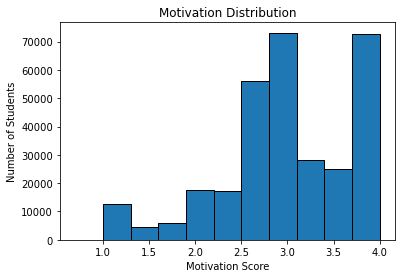

```python
# Create appropriate bins
binsize = 0.3
bins = np.arange(df['motivation'].min()-binsize, df['motivation'].max()+binsize, binsize)

# Plot
plt.hist(data = df, x = 'motivation', bins = bins, histtype='bar', ec='black')
plt.title('Motivation Distribution')
plt.ylabel('Number of Students')
plt.xlabel('Motivation Score');
```

**The graph is slightly left skewed indicating that the students are more likely to be motivated than demotivated which is a good sign**

### Internet Possession

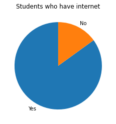

```python
plt.pie(df['internet_possession'].value_counts(), labels=df['internet_possession'].value_counts().index,startangle=90)
plt.title('Students who have internet');
```

**Clearly most students have internet and this makes sense since we're in the 21st century**

### Discuss the distribution(s) of your variable(s) of interest. Were there any unusual points? Did you need to perform any transformations?

It seems that the only variable with unusual points is the wealth index since it has outliers and this didn't show in any of the other features so it has to be investigated later.

### Of the features you investigated, were there any unusual distributions? Did you perform any operations on the data to tidy, adjust, or change the form of the data? If so, why did you do this?

Concerning the data distributions, there wasn't actually any unusual distribution but what was fascinating to me that the larger number of students are motivated and actually having normal distributions for the scores and a 50-50% of gender distribution is a good sign that the data is not biased.

## Bivariate Exploration

### Gender and Math Score

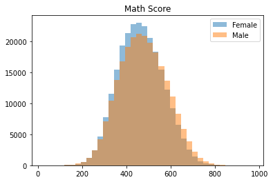

```python
binsize=25
bins=np.arange(min(df['math_score']),max(df['math_score'])+binsize, binsize)

plt.title('Math Score')
plt.hist(data=df.query('gender=="Female"'),x='math_score', alpha=0.5,bins=bins,label='Female')
plt.hist(data=df.query('gender=="Male"'),x='math_score', alpha=0.5,bins=bins, label='Male')
plt.legend();
```

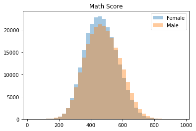

```python
binsize=25
bins=np.arange(min(df['math_score']),max(df['math_score'])+binsize, binsize)

plt.title('Math Score')
plt.hist(data=df.query('gender=="Female"'),x='math_score', alpha=.4,bins=bins,label='Female')
plt.hist(data=df.query('gender=="Male"'),x='math_score', alpha=.4,bins=bins, label='Male')
plt.legend();
```

### Gender and Motivation

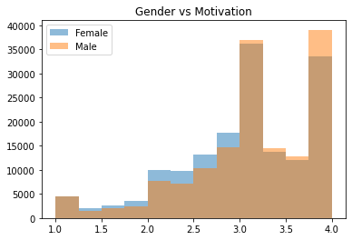

```python
binsize=0.25
bins=np.arange(min(df['motivation']),max(df['motivation'])+binsize, binsize)
plt.title('Gender vs Motivation')
plt.hist(data=df.query('gender=="Female"'),x='motivation', alpha=0.5,bins=bins,label='Female')
plt.hist(data=df.query('gender=="Male"'),x='motivation', alpha=0.5,bins=bins, label='Male')
plt.legend();
```

**This also shows that males are more motivated than females**

### Motivation & Scores

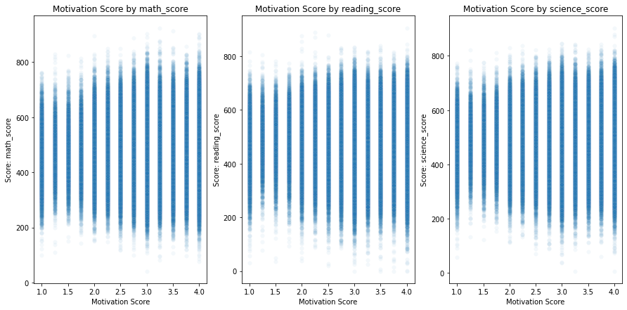

```python
fig, ax= plt.subplots(nrows=1,ncols=3,figsize=[15,7])
ax=ax.flatten()

i=0
scores = ['math_score','reading_score','science_score']
for course in scores:
    plt.sca(ax[i])

    sb.scatterplot(x=df['motivation'],y=df[course],alpha=.05)
    ax[i].set_ylabel('Score: {}'.format(course))
    ax[i].set_xlabel('Motivation Score')
    ax[i].set_title('Motivation Score by {}'.format(scores[i]))
    i+=1
```

**Motivation doesn't seem to be highly correlated with any of the different courses' scores**

### Top countries with cleverest students

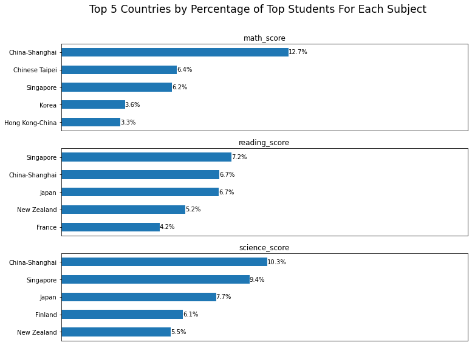

```python
def top_countries(score):
    # Create a copy of original dataframe
    df_copy = df.copy()

    # We'll consider the upper quartile students
    upperQ = df_copy[score].max() * 0.75

    # Create top attribute
    df_copy['top'] = df_copy[score] > upperQ

    # Find percentage of top students in countries
    topStudentsCountries = df_copy.groupby('country').top.mean().mul(100)

    # Plot
    #sort values sorts the data asscendingly so we take the last 5 values which represent the largest values
    topStudentsCountries.sort_values().tail(5).plot(kind='barh')
    plt.xlim(0, topStudentsCountries.max() + 10)
    plt.title(score)
    plt.xlabel(None)
    plt.ylabel(None)


    plt.tick_params(axis='x', which='both', bottom=False, top=False, labelbottom=False)

    # Write the total number after the bar
    indexes, labels = plt.yticks()
    for index, label in zip(indexes, labels):
        value = topStudentsCountries[label.get_text()]
        plt.text(y=index, x=value, s='{:.1f}%'.format(value), va='center')

plt.figure(figsize=[12, 9])
plt.suptitle('Top 5 Countries by Percentage of Top Students For Each Subject', size='xx-large')

# Plot Math
plt.subplot(3, 1, 1)
top_countries('math_score')

# Plot Reading
plt.subplot(3, 1, 2)
top_countries('reading_score')

# Plot Science
plt.subplot(3, 1, 3)
top_countries('science_score')


plt.savefig('topCountries.png')
```

### A heatmap to check for correlation with different features

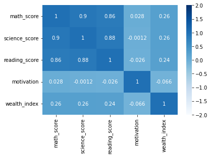

```python
sb.heatmap(data=df[['math_score','science_score','reading_score','motivation','wealth_index']].corr(),
           center=0, cmap="Blues",annot=True, vmin=-2, vmax=2);
```

### A pairplot for correlation

```python
numeric_vars = ['math_score', 'reading_score', 'science_score', 'wealth_index']
categoric_vars = ['gender', 'internet_possession']
```

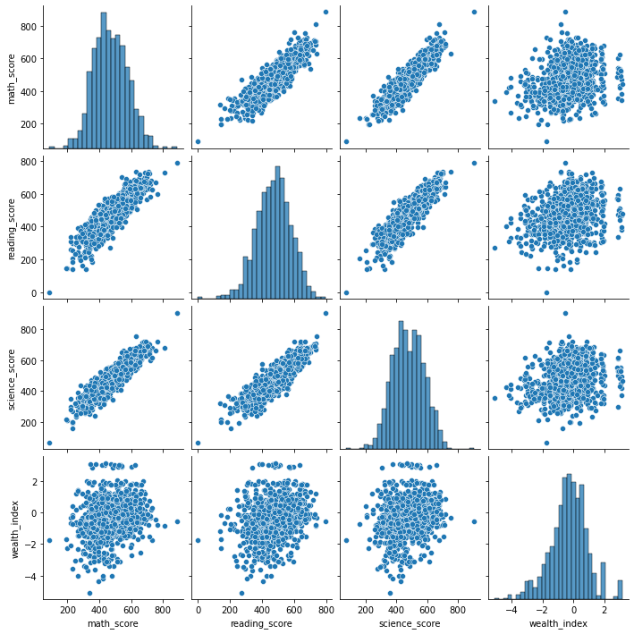

```python
# Let's take a sample of 1000 students for faster processing
samples = np.random.choice(df.shape[0], 1000, replace=False)
students_sample = df.loc[samples, :]

sb.pairplot(data=students_sample, vars=numeric_vars);
```

**As we found previously, there's a strong correlation between math, reading and science scores. And we can see a very weak correlation between scores and wealth index --> this shows that wealth is not related to being successful.**

**Also the graphs indicate that math and science have the highest correlation, however the math and reading correlation is the weakest.**

### The effect of the 2 categorical variables, gender & internet possession on academic scores

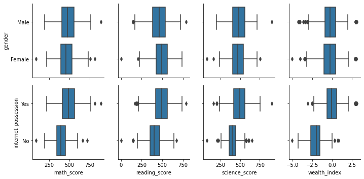

```python
def boxgrid(x, y, **kwargs):
    sb.boxplot(x, y, color=base_color)


g = sb.PairGrid(data=students_sample, x_vars=numeric_vars, y_vars=categoric_vars)
g.map(boxgrid);
```

Realizations from this plot:

- Female students have higher reading scores on average
- Male students have slightly higher wealth index on average
- The internet possession has a high correlation with academic performance and wealth index

### Talk about some of the relationships you observed in this part of the investigation. How did the feature(s) of interest vary with other features in the dataset?

It was interesting to find that students with high scores in a subject are also clever and score high grades in other subjects,also I liked the facts that females are not more clever as people this and that being a wealthy student doesn't ensure being successful.

### Did you observe any interesting relationships between the other features (not the main feature(s) of interest)?

I found it very weird that male students on average have higher wealth index than females, and why female students score better than males in the reading course specifically..

## Multivariate Exploration

### Scores and Gender

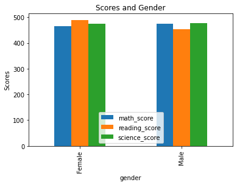

```python
data = df.groupby('gender')[['math_score', 'reading_score', 'science_score']].mean()
ax = data.plot.bar()
plt.ylabel('Scores')
plt.title('Scores and Gender');

plt.savefig('scoresAndGender')
```

**This plot helped us identify exactly which gender exceeds the other in the specific subjects. For instance, males are more clever in math than females, however females outperform the males in reading. Both of them are almost equivalent when it comes to science**

## Score and Internet Possession

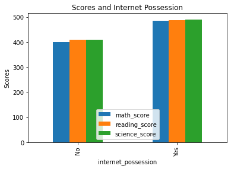

```python
data = df.groupby('internet_possession')[['math_score', 'reading_score', 'science_score']].mean()
ax = data.plot.bar()
plt.ylabel('Scores')
plt.title('Scores and Internet Possession');
```

**This perfectly confirms my theory that internet possession significantly affects the scores in a superb way**

### Top performers based on gender and country in Math

```python
df['math_score'].max()
```

```
962.2293
```

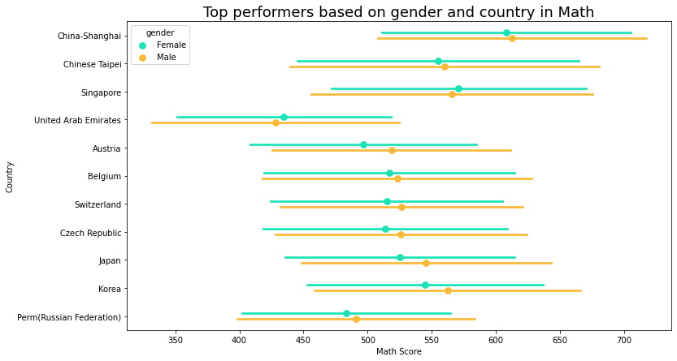

```python
plt.figure(figsize=(12,7))
high_math_score= df[df['math_score']>850]['country'].value_counts()

ax = sb.pointplot(data = df, y = 'country', x = 'math_score', hue = 'gender',order= high_math_score.index,
                  dodge = 0.2, ci = 'sd', palette = 'turbo', linestyles = "")
plt.xlabel('Math Score')
plt.ylabel('Country')
plt.title('Top performers based on gender and country in Math', fontsize= 18);
```

**Males appear to be leading in the math scores in every country (as we previously mentioned), but the new thing here is that in Singapore and United Arab Emirated, females were the top performers not males**

### Top performers based on gender and country in Reading

```python
df['reading_score'].max()
```

```
904.8026
```

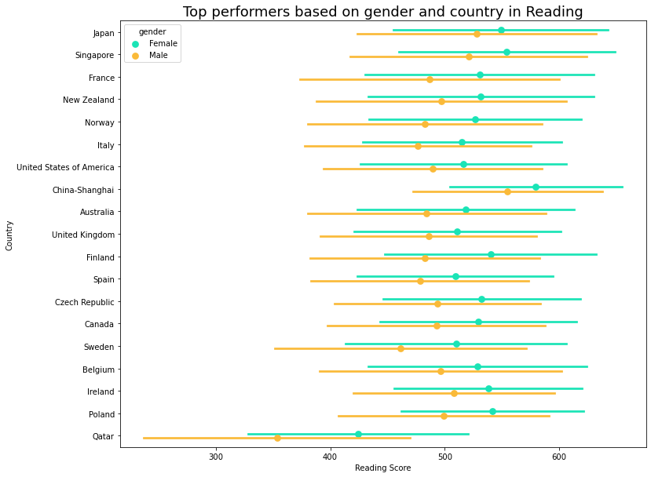

```python
plt.figure(figsize=(12,10))
high_reading_score= df[df['reading_score']>800]['country'].value_counts()

ax = sb.pointplot(data = df, y = 'country', x = 'reading_score', hue = 'gender',order= high_reading_score.index,
                  dodge = 0.2, ci = 'sd', palette = 'turbo', linestyles = "")
plt.xlabel('Reading Score')
plt.ylabel('Country')
plt.title('Top performers based on gender and country in Reading', fontsize= 18);
```

**Impressive! This plot obviously shows that females are the world's top performers in reading**

### Top performers based on gender and country in Science

```python
df['science_score'].max()
```

```
903.3383
```

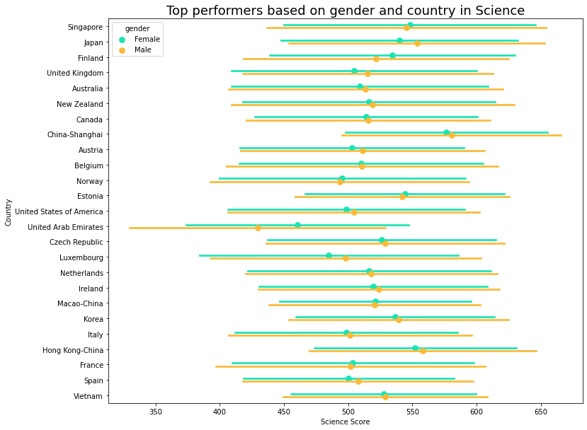

```python
plt.figure(figsize=(12,10))
high_science_score= df[df['science_score']>800]['country'].value_counts()

ax = sb.pointplot(data = df, y = 'country', x = 'science_score', hue = 'gender',order= high_science_score.index,
                  dodge = 0.2, ci = 'sd', palette = 'turbo', linestyles = "")
plt.xlabel('Science Score')
plt.ylabel('Country')
plt.title('Top performers based on gender and country in Science', fontsize= 18);
```

**This point plot confirms our previous claim that males and females are competing together when it comes to Science. You cannot identify a certain pattern here whether males or females are leading in most of the countries.**

### Talk about some of the relationships you observed in this part of the investigation. Were there features that strengthened each other in terms of looking at your feature(s) of interest?

**The multivariate exploration confirmed our conclusions in the previous plots, here are the points:**

1. Females outperform males when it comes to reading
2. Males outperform females when it comes to math, except for 2 countries (which is a new exploration).
3. Males & Females almost have the same scores concerning the science

### Were there any interesting or surprising interactions between features?

1. As I mentioned, the 2 countries that contradict the male leading math score is a new fact
2. In Singapore, I found that in every course the females are outperforming the males, that's why I'll check the gender distribution for this country, maybe there are more girls.

```python
df[df['country']=='Singapore'].gender.value_counts()
```

```
Male      2794
Female    2752
Name: gender, dtype: int64
```

**Clearly, the gender is evenly split for Singapore so this confirms that females in this country outperform the males**